# Final Project Proposal

Dylan Fu

2023-03-19

```r
library(tidyr)
library(stringr)
library(tidymodels)
library(tidyverse)
library(glmnet)
library(modeldata)
library(kknn)
library(janitor)
library(doParallel)
registerDoParallel(cores = parallel::detectCores())
library(vip)
```

```r
library(ggplot2)
library(fastDummies)
library(kableExtra)
#pretty table func
kable <- function(data, scroll=TRUE) {
    knitr::kable(data, booktabs = TRUE) |>
    kable_styling(full_width=TRUE, latex_options = c("striped", "scale_down")) |>
    (\(.) if (scroll) scroll_box(., height = "200px") else .)()
}
```

# Introduction

The dataset that I’ll be using for my final project is Yelp’s restaurant dataset. (found at [Yelp Dataset](https://www.yelp.com/dataset/documentation/main)) It has over 150,000 observations and 15 predictors, with both quantitative and qualitative predictors. There are no missing (NA) values in the dataset.

```r
yelp_businesses<-read.csv('C:/Users/Dylan Fu/Desktop/file.csv')
```

```r
nrow(yelp_businesses)
```

```
## [1] 150346
```

```r
sum(is.na(yelp_businesses))
```

```
## [1] 0
```

```r
sapply(yelp_businesses, class)
```

```
##            X  business_id         name      address         city        state
##    "integer"  "character"  "character"  "character"  "character"  "character"
##  postal_code     latitude    longitude        stars review_count      is_open
##  "character"    "numeric"    "numeric"    "numeric"    "integer"    "integer"
##   attributes   categories        hours
##  "character"  "character"  "character"
```

# Research Question

My question is, “Can I build a machine learning model to predict the Yelp score of a restaurant?”

The variable I’m interested in predicting is stars, Yelp’s aggregate review score out of a maximum of 5. I want to see if I can predict a restaurant’s rating based on other variables such as location, price, etc. This problem is best approached as a regression task, as my response variable is numeric. I believe that predictors such as “attributes”, “categories” and “review count” will be particularly helpful. The goal of my model is both predictive and inferential. I want to be able to predict a restaurant’s score and learn what attributes may influence score.

# Cleaning the Data

First, I excluded non-restaurant/food related observations by filtering on the word “Food” to remove non-restaurant observations. Then I filtered on is_open and review_count to exude observations with fewer than 30 reviews and restaurants that had closed down.

```r
yelp_res<-yelp_businesses%>%filter(str_detect(yelp_businesses$categories, pattern = 'Food'))%>%filter(is_open == 1)%>%filter(review_count>=30)
```

```r
yelp_sep<-separate_rows(yelp_res,categories)
yelp_sep$categories<-yelp_sep$categories%>%fct_lump_n(80)%>%fct_lump
yelp_dum<-dummy_cols(.data = yelp_sep, select_columns = 'categories', remove_selected_columns = T)
```

Finally, I excluded duplicate rows and merged together rows to create unique rows with all dummy coded variables as well as filtering on `categories_Restaurant` to filter out any remaining non-restaurants.

```r
yelp_dum<-unique(yelp_dum)
yelp_final<-yelp_dum%>%group_by(business_id)%>%summarise(across(categories_American:categories_Other,sum))
yelp_final<-yelp_final%>%filter(categories_Restaurants == 1)
yelp_final<-left_join(yelp_final, distinct(yelp_dum%>%select(business_id, stars,state, review_count)))
yelp_final<-yelp_final%>%mutate(across(contains("categories"),as.double))
```

# Exploratory Data Analysis

Review scores are not uniformly distributed, most scores lie within the 3.5 to 4.5 range.

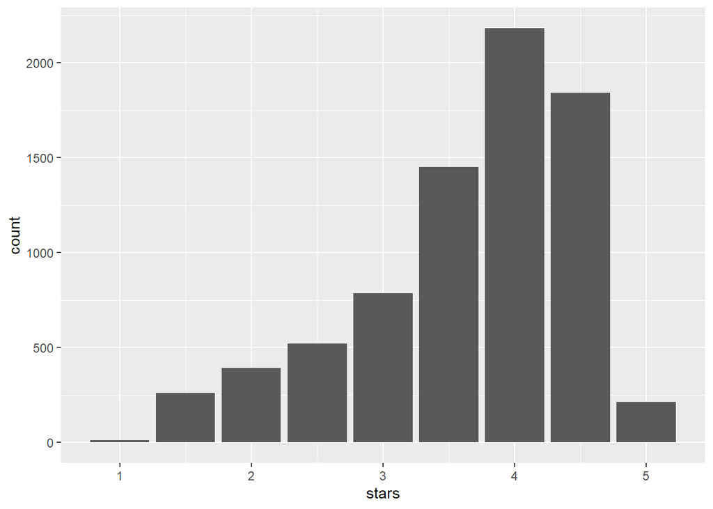

```r
ggplot(yelp_final,aes(stars))+geom_bar()
```

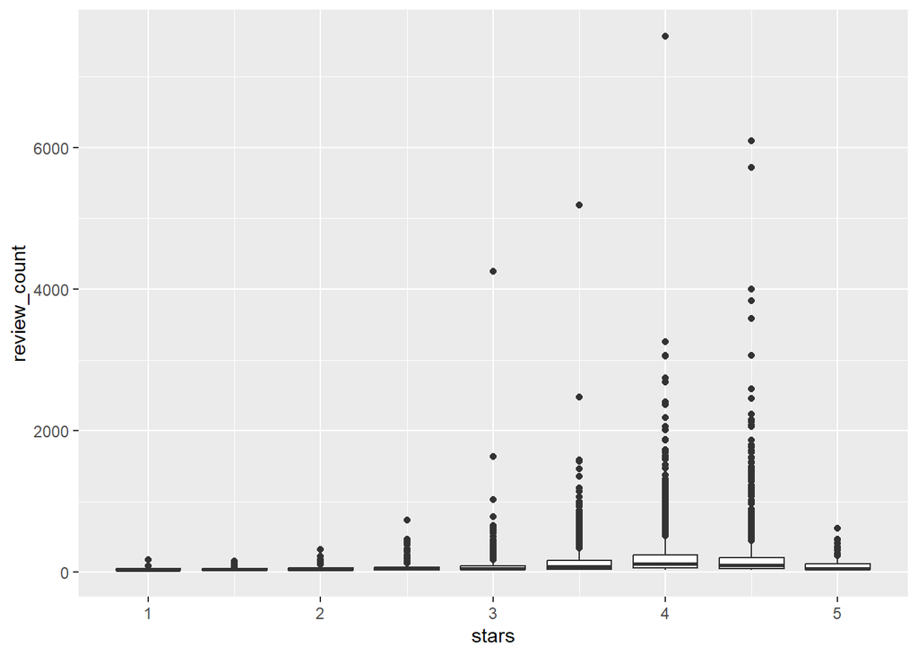

```r
ggplot(yelp_final, aes(stars, group= stars ,review_count))+geom_boxplot()
```

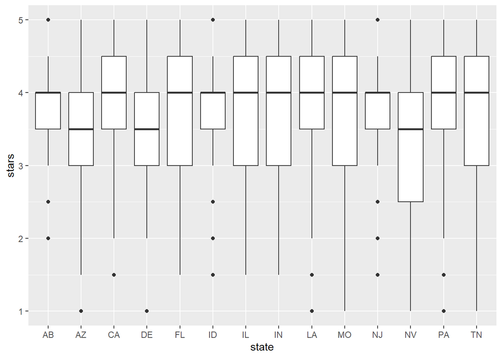

```r
ggplot(yelp_final, aes(state, stars))+geom_boxplot()
```

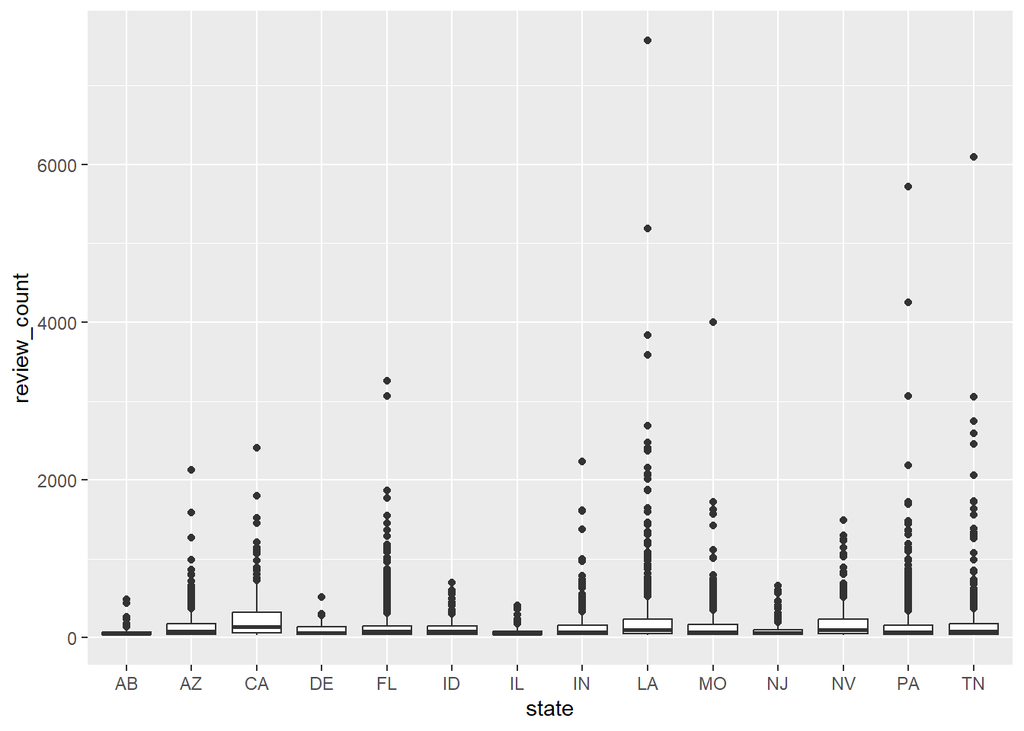

```r
ggplot(yelp_final, aes(state, review_count))+geom_boxplot()
```

# Creating Models

## Splitting Data

I split my data into train/test splits with a ratio of .7 while stratifying on `stars` to account for the fact that there are far fewer restaurants with extreme star ratings. Then, I split my training set into a further 10 folds, also stratified by `stars`. Cross validation allows me to predict generally how my models will perform on the testing set without causing data leakage by actually applying them to the testing set.

```r
df_rating<-yelp_final%>%select(!c(business_id, categories_Restaurants, categories_Food))
df_rating<-clean_names(df_rating)
df_split<-initial_split(df_rating, prop=.7, strata = stars)
df_train<-training(df_split)
df_fold<-vfold_cv(df_train, v = 10, strata = stars)
df_test<-testing(df_split)
```

## Creating Recipe

```r
df_rec<-recipe(stars~., data=df_train)%>%step_dummy(state)
```

## Building Models

I set up models, workflows and grids for linear regression, elastic net regression, k-nearest neighbors, and random forest machine learning models.

```r
#LINEAR REGRESSION
lm_model<-linear_reg()%>%set_engine("lm")
lm_wk<-workflow()%>%add_model(lm_model)%>%add_recipe(df_rec)

#K-NEAREST NEIGHBORS
kn_model<-nearest_neighbor(neighbors = tune()) %>%
  set_engine("kknn") %>% set_mode("regression")
kn_wk<-workflow()%>%add_model(kn_model)%>%add_recipe(df_rec)

#ELASTIC NET
glm_model<- linear_reg(mixture = tune(), penalty = tune()) %>%set_mode("regression")%>%set_engine("glmnet")
glm_wk<-workflow()%>%add_model(glm_model)%>%add_recipe(df_rec)
# RANDOM FOREST

rf_model <- rand_forest(mtry = tune(),
                       trees = tune(),
                       min_n = tune()) %>%
  set_engine("ranger", importance = "impurity") %>%
  set_mode("regression")
rf_wk<-workflow()%>%add_model(rf_model)%>%add_recipe(df_rec)
```

## Create Tuning Grids

The hyperparameter ranges that I chose were based on my understanding of my computer’s ability to run the tuning in a timely fashion. Random forest had mtry between 1 and 20, trees between 200 and 1000, and min_n between 5 and 20. K-nearest neighbors had neighbors between 1 and 20, and Elastic Net was tuned as usual.

```r
# RANDOM FOREST
rf_grid<- grid_regular(mtry(range = c(1, 20)), trees(range = c(200,1000)), min_n(range = c(5,20)), levels = 20)
#K-NEAREST NEIGHBORS
ykn_grid<- grid_regular(neighbors(range = c(1, 20)), levels=20)
#ELASTIC NET REGRESSION
glm_grid <- grid_regular(penalty(range = c(0, 1),
                                     trans = identity_trans()),
                        mixture(range = c(0, 1)),
                             levels = 10)
```

## Fitting Models

I then fit models onto the CV set using `tune_grid()`, saving my results for comparison later on.

```r
# LINEAR REGRESSION
lm_fit <- fit_resamples(lm_wk, resamples = df_fold)
lm_metrics <- collect_metrics(lm_fit)
```

```r
tune_kn_grid<-tune_grid(kn_wk, resamples = df_fold, grid=ykn_grid)
best_kn<-select_best(tune_kn_grid, metric = "rmse", neighbors)
kn_wk_train<-finalize_workflow(kn_wk, best_kn)
kn_final_fit<-fit_resamples(kn_wk_train, resamples = df_fold)
kn_metrics<-collect_metrics(kn_final_fit)
```

```r
tune_glm_grid<-tune_grid(glm_wk, resamples = df_fold, grid = glm_grid)
best_glm<-select_best(tune_glm_grid, metric = 'rmse', penalty, mixture)
glm_wk_train<-finalize_workflow(glm_wk, best_glm)
glm_final_fit<-fit_resamples(glm_wk_train, resamples = df_fold)
glm_metrics<-collect_metrics(glm_final_fit)
```

```r
rf_tune_grid <- tune_grid(
  rf_wk,
  resamples = df_fold,
  grid = rf_grid, control = control_grid(verbose = TRUE)
)
save(rf_tune_grid, file='rf_tune_grid.rda')
```

```r
load('rf_tune_grid.rda')
best_rf<-select_best(rf_tune_grid, metric = "rmse", mtry, trees, min_n)
rf_wk_train<-finalize_workflow(rf_wk, best_rf)
rf_final_fit<-fit_resamples(rf_wk_train, resamples = df_fold)
rf_metrics<-collect_metrics(rf_final_fit)
```

## Comparing Models

```r
final_compare_tibble <- tibble(Model = c("Linear Regression", "K Nearest Neighbors" ,"Elastic Net", "Random Forest"), RMSE = c(lm_metrics$mean[1],kn_metrics$mean[1], glm_metrics$mean[1], rf_metrics$mean[1]))
final_compare_tibble <- final_compare_tibble %>%
  arrange(RMSE)
final_compare_tibble%>%kable()
```

| Model | RMSE |
| --- | --- |
| Random Forest | 0.5581759 |
| K Nearest Neighbors | 0.6242098 |
| Elastic Net | 0.6542889 |
| Linear Regression | 0.6548712 |

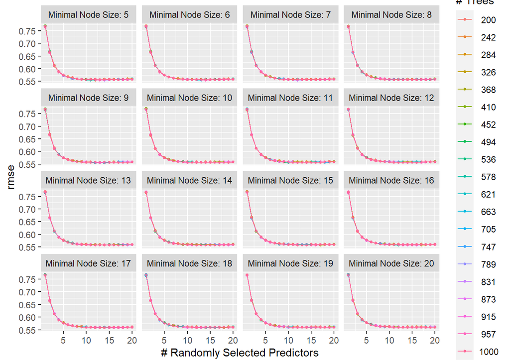

```r
autoplot(rf_tune_grid, metric = "rmse")
```

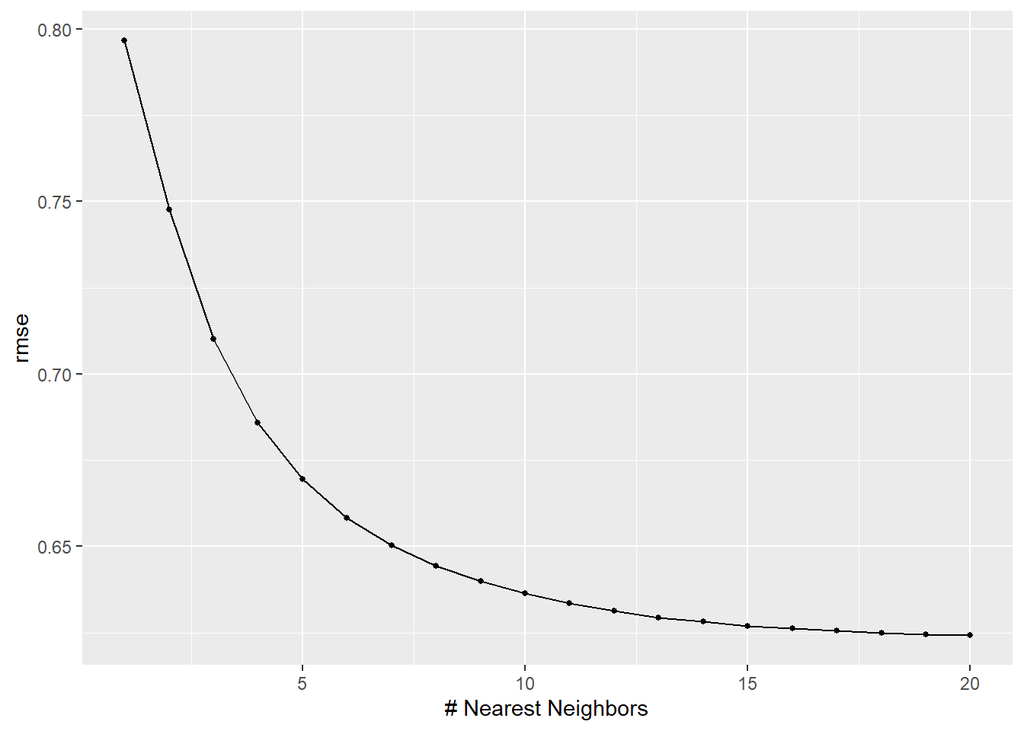

```r
autoplot(tune_kn_grid, metric = "rmse")
```

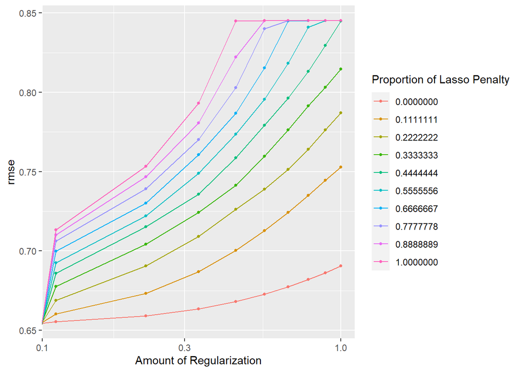

```r
autoplot(tune_glm_grid, metric = "rmse")
```

## Fitting on Testing Set

The random forest model had similar performance on the testing set as it had on the training and CV sets.

```r
rf_final_fit<-fit(rf_wk_train, df_train)
aug_test<-augment(rf_final_fit, df_test)
multi_metric<-metric_set(rmse,rsq,mae)
multi_metric(aug_test, stars, .pred)
```

| .metric | .estimator | .estimate |
| --- | --- | --- |
| rmse | standard | 0.5513251 |
| rsq | standard | 0.5565810 |
| mae | standard | 0.4310425 |

# Conclusion

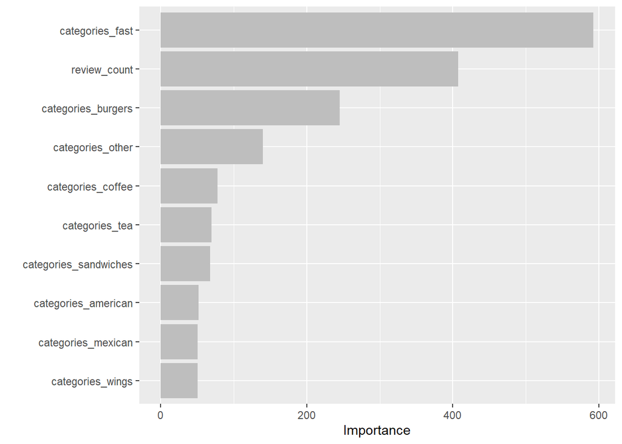